changelog

1. lena图在新版skimage已经移除，换成cat
2. hist()中hold=1报错

# 2.1 直方图与均衡化

## 直方图

### 1、计算直方图

skimage 库中对直方图的处理，是放在 exposure 这个模块中，numpy 包中，也提供了一个计算直方图的函数 histogram(),两者大同小异。

而 skimage 返回的是每个 bin 的中间值，numpy 返回的是每个 bin 的两端的范围值。

```python
import numpy as np
from skimage import exposure,data
image =data.camera()*1.0
hist1=np.histogram(image, bins=2) #用 numpy 包计算直方图
hist2=exposure.histogram(image, nbins=2) #用 skimage 计算直方图
print(hist1)
print(hist2)
```

```
(array([ 93585, 168559], dtype=int64), array([  0. , 127.5, 255. ]))
(array([ 93585, 168559], dtype=int64), array([ 63.75, 191.25]))
```

### 2、绘制直方图

绘图都可以调用 matplotlib.pyplot 库来进行，其中的 hist 函数可以直接绘制直方图。

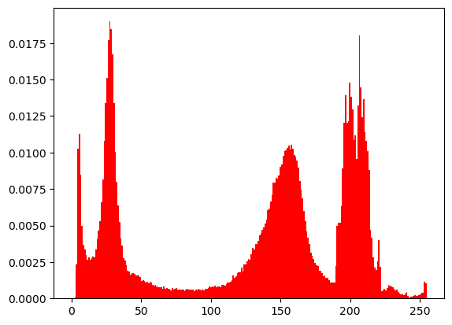

```python
from skimage import data
import matplotlib.pyplot as plt
img=data.camera()
plt.figure("hist")
arr=img.flatten()
n, bins, patches = plt.hist(arr, bins=256, density=1,edgecolor='None',facecolor='red')
plt.show()
```

```
hist 函数调用方式：
n, bins, patches = plt.hist(arr, bins=10, normed=0, facecolor='black', edgecolor='black',alpha=1，histtyp
e='bar')

# hist 的参数非常多，但常用的就这六个，只有第一个是必须的，后面四个可选
# arr: 需要计算直方图的一维数组
# bins: 直方图的柱数，可选项，默认为 10
# normed: 是否将得到的直方图向量归一化。默认为 0 (python 新版使用 density)
# facecolor: 直方图颜色
# edgecolor: 直方图边框颜色
# alpha: 透明度
# histtype: 直方图类型，‘bar’, ‘barstacked’, ‘step’, ‘stepfilled’
# 返回值 ：
# n: 直方图向量，是否归一化由参数 normed 设定
# bins: 返回各个 bin 的区间范围
# patches: 返回每个 bin 里面包含的数据，是一个 list
```

`flatten()`函数是 numpy 包里面的，用于将二维数组序列化成一维数组。 是按行序列，如

```
mat=[[1 2 3
 4 5 6]]
```

经过 `mat.flatten()`后，就变成了

```
mat=[1 2 3 4 5 6]
```

### 3、彩色图片三通道直方图

一般来说直方图都是征对灰度图的，如果要画 rgb 图像的三通道直方图，实际上就是三 个直方图的叠加。

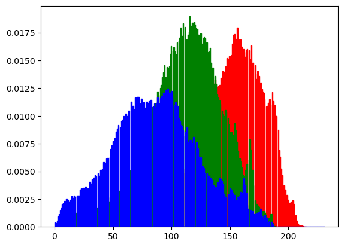

```python
from skimage import data
import matplotlib.pyplot as plt
img=data.cat()
ar=img[:,:,0].flatten()
plt.hist(ar, bins=256, density=1,facecolor='r',edgecolor='r')
ag=img[:,:,1].flatten()
plt.hist(ag, bins=256, density=1, facecolor='g',edgecolor='g')
ab=img[:,:,2].flatten()
plt.hist(ab, bins=256, density=1, facecolor='b',edgecolor='b')
plt.show()
```

## 均衡化

如果一副图像的像素占有很多的灰度级而且分布均匀，那么这样的图像往往有高对比度和多变的灰度色调。直方图均衡化就是一种能仅靠输入图像直方图信息自动达到这种效果的变换函数。它的基本思想是对图像中像素个数多的灰度级进行展宽，而对图像中像素个数少的灰度进行压缩，从而扩展取值的动态范围，提高了对比度和灰度色调的变化，使图像更加清晰。

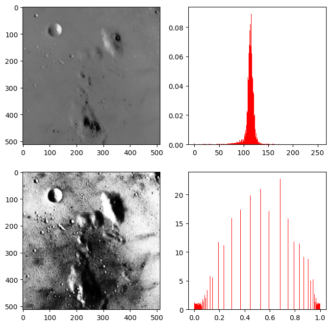

```python
from skimage import data,exposure
import matplotlib.pyplot as plt
img=data.moon()
plt.figure("hist",figsize=(8,8))
arr=img.flatten()
plt.subplot(221)
plt.imshow(img,plt.cm.gray) #原始图像
plt.subplot(222)
plt.hist(arr, bins=256, density=1,edgecolor='None',facecolor='red') #原始图像直方图
img1=exposure.equalize_hist(img)
arr1=img1.flatten()
plt.subplot(223)
plt.imshow(img1,plt.cm.gray) #均衡化图像
plt.subplot(224)
plt.hist(arr1, bins=256, density=1,edgecolor='None',facecolor='red') #均衡化直方图
plt.show()
```

# 2.2 图像简单滤波

对图像进行滤波，可以有两种效果：一种是平滑滤波，用来抑制噪声；另一种是微分算 子，可以用来检测边缘和特征提取。

skimage 库中通过 filters 模块进行滤波操作。

## 边缘检测

`filters.sobel(image, mask=None)`

`filters.roberts(img)`

`filters.scharr(img)`

`filters.prewitt(img)`

`feature.canny(image，sigma=1.0)`可以修改 sigma 的值来调整效果

[figure not shown]

```python
from skimage import data,filters
import matplotlib.pyplot as plt
img = data.camera()
edges = filters.sobel(img)
plt.imshow(edges,plt.cm.gray)
plt.show()
```

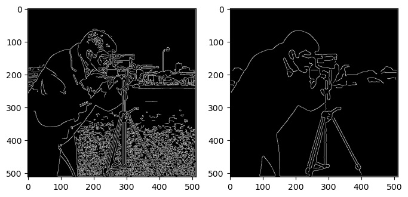

```python
from skimage import data,filters,feature
import matplotlib.pyplot as plt
img = data.camera()
edges1 = feature.canny(img) #sigma=1
edges2 = feature.canny(img,sigma=3) #sigma=3
plt.figure('canny',figsize=(8,8))
plt.subplot(121)
plt.imshow(edges1,plt.cm.gray)
plt.subplot(122)
plt.imshow(edges2,plt.cm.gray)
plt.show()
```

## gabor 滤波

可用来进行边缘检测和纹理特征提取。

通过修改 frequency 值来调整滤波效果，返回一对边缘结果，一个是用真实滤波核的滤波结果，一个是想象的滤波核的滤波结果。

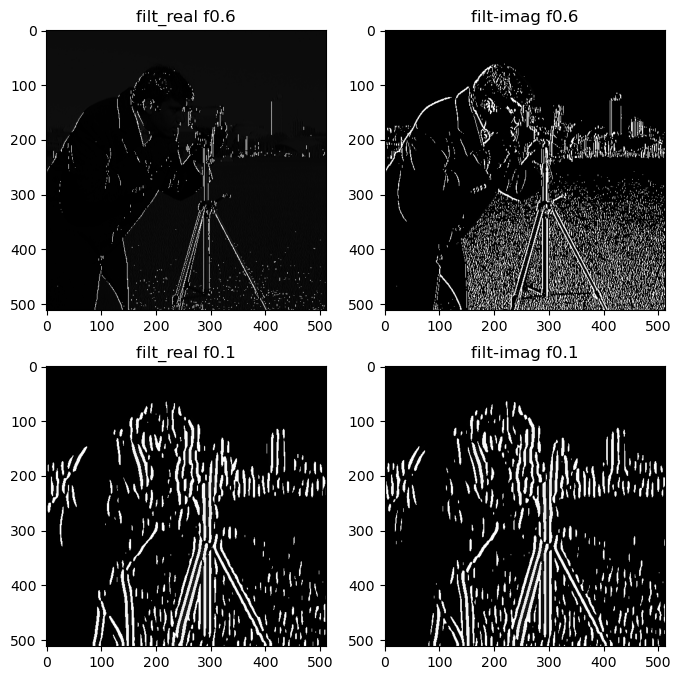

```python
from skimage import data,filters
import matplotlib.pyplot as plt
img = data.camera()
filt_real, filt_imag = filters.gabor(img,frequency=0.6)
plt.figure('gabor',figsize=(8,8))

plt.subplot(221)
plt.title('filt_real f0.6')
plt.imshow(filt_real,plt.cm.gray)
plt.subplot(222)
plt.title('filt-imag f0.6')
plt.imshow(filt_imag,plt.cm.gray)

filt_real, filt_imag = filters.gabor(img,frequency=0.1)
plt.subplot(223)
plt.title('filt_real f0.1')
plt.imshow(filt_real,plt.cm.gray)
plt.subplot(224)
plt.title('filt-imag f0.1')
plt.imshow(filt_imag,plt.cm.gray)

plt.show()
```

## gaussian 滤波

多维的滤波器，是一种平滑滤波，可以消除高斯噪声。

调用函数为：`skimage.filters.gaussian_filter(image, sigma)`

通过调节 sigma 的值来调整滤波效果，sigma 越大，过滤后的图像越模糊。

[figure not shown]

```python
from skimage import data,filters
import matplotlib.pyplot as plt
img = data.astronaut()
edges1 = filters.gaussian(img,sigma=0.4) #sigma=0.4
edges2 = filters.gaussian(img,sigma=5) #sigma=5
plt.figure('gaussian',figsize=(8,8))
plt.subplot(121)
plt.imshow(edges1,plt.cm.gray)
plt.subplot(122)
plt.imshow(edges2,plt.cm.gray)
plt.show()
```

## median

中值滤波，一种平滑滤波，可以消除噪声。

需要用 skimage.morphology 模块来设置滤波器的形状。

滤波器越大，图像越模糊。

[figure not shown]

```python
from skimage import data,filters
import matplotlib.pyplot as plt
from skimage.morphology import disk
img = data.camera()
edges1 = filters.median(img,disk(5))
edges2= filters.median(img,disk(9))
plt.figure('median',figsize=(8,8))
plt.subplot(121)
plt.imshow(edges1,plt.cm.gray)
plt.subplot(122)
plt.imshow(edges2,plt.cm.gray)
plt.show()
```

## 水平、垂直边缘检测

上边所举的例子都是进行全部边缘检测，有些时候我们只需要检测水平边缘，或垂直边 缘，就可用下面的方法。

水平边缘检测：`sobel_h, prewitt_h, scharr_h`

垂直边缘检测： `sobel_v, prewitt_v, scharr_v`

[figure not shown]

```python
from skimage import data,filters
import matplotlib.pyplot as plt
img = data.camera()
edges1 = filters.sobel_h(img)
edges2 = filters.sobel_v(img)
plt.figure('sobel_v_h',figsize=(8,8))
plt.subplot(121)
plt.title('Horizontal')
plt.imshow(edges1,plt.cm.gray)


plt.subplot(122)
plt.title('Vertical')
plt.imshow(edges2,plt.cm.gray)
plt.show()
```

## 交叉边缘检测

可使用 Roberts 的十字交叉核来进行过滤，以达到检测交叉边缘的目的。这些交叉边缘 实际上是梯度在某个方向上的一个分量。

其中一个核：

0 1

-1 0

对应的函数： `roberts_neg_diag(image）`

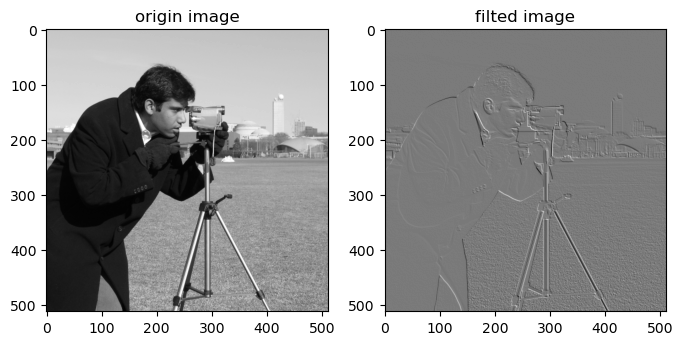

```python
from skimage import data,filters
import matplotlib.pyplot as plt
img =data.camera()
dst =filters.roberts_neg_diag(img)
plt.figure('filters',figsize=(8,8))
plt.subplot(121)
plt.title('origin image')
plt.imshow(img,plt.cm.gray)
plt.subplot(122)
plt.title('filted image')
plt.imshow(dst,plt.cm.gray)
plt.show()
```

另外一个核：

1 0

0 -1

对应函数为：`roberts_pos_diag(image)`

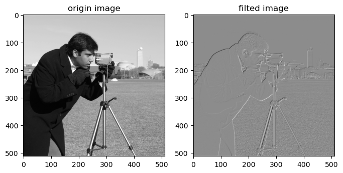

```python
from skimage import data,filters
import matplotlib.pyplot as plt
img =data.camera()
dst =filters.roberts_pos_diag(img)
plt.figure('filters',figsize=(8,8))
plt.subplot(121)
plt.title('origin image')
plt.imshow(img,plt.cm.gray)
plt.subplot(122)
plt.title('filted image')
plt.imshow(dst,plt.cm.gray)
plt.show()
```